# Individual tree basal area increment models for broadleaved forests in Bhutan | Forestry: An International Journal of Forest Research | Oxford Academic

## Introduction

Mountain forests are rich repositories of biodiversity. They provide various ecosystem services important to sustain rural livelihoods and national development. Nevertheless, there is a threat that the mountain forests are increasingly managed with unsustainable agricultural and forestry practices ([Sundriyal and Sharma, 1996](https://academic.oup.com/forestry/article/90/3/367/2958336); [Wakeel *et al*., 2005](https://academic.oup.com/forestry/article/90/3/367/2958336)). With a forest cover of 70.5% ([Ministry of Agriculture and Forests, 2010](https://academic.oup.com/forestry/article/90/3/367/2958336)) the Bhutan Himalaya has the highest forest cover in the region. Broadleaved forests cover an area of about 1.69 million hectares ([Department of Forests & Park Services, 2014](https://academic.oup.com/forestry/article/90/3/367/2958336)), representing more than half of the total forested area in Bhutan. The broadleaved forests are an important asset as they provide services to about 80% of the population. A key condition for ensuring sustainable supply of forest resources is a forest management plan based on: (1) correct assessment of resources and (2) volume increment predictions derived from growth models ([Monserud and Sterba, 1996](https://academic.oup.com/forestry/article/90/3/367/2958336); [Tarp-Johansen *et al*., 1997](https://academic.oup.com/forestry/article/90/3/367/2958336); [Da Silva *et al*., 2002](https://academic.oup.com/forestry/article/90/3/367/2958336); [Hasenauer *et al*., 2012](https://academic.oup.com/forestry/article/90/3/367/2958336); [Tenzin *et al*., 2016](https://academic.oup.com/forestry/article/90/3/367/2958336)).

Forest management in Bhutan is based on guidelines published by the Department of Forests & Park Services (DoFPS), Ministry of Agriculture & Forests (MoAF). Currently about 9% of the forests in Bhutan are under approved management plans to supply timber and non-timber forest products from forest management units (FMUs) and community forests (CFs) ([Department of Forests & Park Services, 2014](https://academic.oup.com/forestry/article/90/3/367/2958336)). Forest areas outside the FMUs and CFs are also used for harvesting to meet the increasing demand for timber and non-timber forest products. Such forest areas are without a management plan and are increasingly degraded due to extraction of resources (timber, fuel wood and non-timber forest products) and disturbances such as grazing ([Tenzin and Hasenauer, 2016](https://academic.oup.com/forestry/article/90/3/367/2958336)). The management plans for these forests are currently being pursued for improving the forest conditions and ensuring their sustainability ([Forest Resources Development Division, 2005](https://academic.oup.com/forestry/article/90/3/367/2958336)).

The practical problem limiting sustainable forest management in Bhutan is that no information on relative increment or species-specific changes in volume growth exists. Without such information, it is impossible to estimate the amount of timber for sustainable harvesting. This suggests the need to calibrate simple increment models to improve sustainable forest management in Bhutan.

One method to calculate increment is by repeatedly measuring marked trees on permanent sample plots. If no repeated tree records are available, increment cores are the best option for deriving diameter growth ([Zumrawi, 1990](https://academic.oup.com/forestry/article/90/3/367/2958336); [Brienen and Zuidema, 2006](https://academic.oup.com/forestry/article/90/3/367/2958336)). However, a precondition is that a distinct seasonality in annual tree rings is evident to ensure growth rates derived from increment cores can be related to tree age. The mountain areas of Bhutan represent a temperate forest system with a distinct seasonality, which leads to the appearance of annual tree rings and thus annual increment rates are possible to determine.

The forests of Bhutan are very rich in tree species, especially in the broadleaved forests zones ([Tenzin and Hasenauer, 2016](https://academic.oup.com/forestry/article/90/3/367/2958336)), which makes the development of species-specific growth models difficult ([Zhao *et al*., 2004](https://academic.oup.com/forestry/article/90/3/367/2958336); [Gourlet-Fleury *et al*., 2005](https://academic.oup.com/forestry/article/90/3/367/2958336); [Akindele and LeMay, 2006](https://academic.oup.com/forestry/article/90/3/367/2958336)). In addition, there is a lack of sufficient data for calibrating species-specific models. Consequently, grouping species and developing equations by species groups are seen to be the best alternative, since it reduces the number of growth functions and enhances the reliability and the practical application of the final results ([Vanclay, 1991](https://academic.oup.com/forestry/article/90/3/367/2958336); [Finegan *et al*., 1999](https://academic.oup.com/forestry/article/90/3/367/2958336); [Akindele and LeMay, 2006](https://academic.oup.com/forestry/article/90/3/367/2958336)).

Individual tree basal area increment (BAI) models are commonly used within growth modelling. They derive tree growth according to tree size, crown size, level of competition and site specific characteristics ([Wykoff, 1990](https://academic.oup.com/forestry/article/90/3/367/2958336); [Hasenauer, 2006](https://academic.oup.com/forestry/article/90/3/367/2958336); [Pokharel and Dech, 2012](https://academic.oup.com/forestry/article/90/3/367/2958336)). The tree size vector includes diameter at breast height (DBH) and its modifications such as DBH<sup>2</sup>, tree height (H) and crown size which is either crown diameter or crown length (CL). The level of competition of a tree within the stand is expressed by competition indices derived from routine inventory data ([Daniels, 1976](https://academic.oup.com/forestry/article/90/3/367/2958336); [Martin and Ek, 1984](https://academic.oup.com/forestry/article/90/3/367/2958336)). Other variables, such as slope, elevation and soil type represent the site specific characteristics ([Wykoff, 1990](https://academic.oup.com/forestry/article/90/3/367/2958336); [Monserud and Sterba, 1996](https://academic.oup.com/forestry/article/90/3/367/2958336)). Such modelling approaches have been developed for temperate forests ([Monserud and Sterba, 1996](https://academic.oup.com/forestry/article/90/3/367/2958336); [Sterba, 2002](https://academic.oup.com/forestry/article/90/3/367/2958336); [Zhao *et al*., 2004](https://academic.oup.com/forestry/article/90/3/367/2958336); [Hasenauer, 2006](https://academic.oup.com/forestry/article/90/3/367/2958336)) and tropical rain forests ([Phillips *et al*., 2002](https://academic.oup.com/forestry/article/90/3/367/2958336); [da Cunha *et al*., 2015](https://academic.oup.com/forestry/article/90/3/367/2958336)), but are lacking for the Himalayan region, including Bhutan.

The main aim of this study was to identify the main factors influencing tree growth within the broadleaved forest zone in Bhutan and provide a first attempt for an individual tree BAI model based on increment cores. The specific objectives of the study were to: (1) provide a method to arrange the large number of species into species groups, (2) identify the main factors important for tree growth, (3) calibrate individual tree BAI models for predicting tree growth by species group and (4) evaluate the practical implementation of our results for broadleaved forest management in the Dagana region of Bhutan.

## Materials and methods

### Study area

The data for this study come from a watershed in Dagana, a district in the south central part of Bhutan within the geographical range of 26°54′16″ to 27°01′36″ north and 89°51′19″ to 89°57′58″ east (Figure [1](https://academic.oup.com/forestry/article/90/3/367/2958336)). It has an area of 6422 ha and lies within the elevation range of 500–2400 m.a.s.l. The mean annual precipitation at two meteorological stations of Daga Dzong (1460 m.a.s.l) and at Drujaygang (1140 m.a.s.l) ranges from 1770 mm to 2020 mm. The maximum precipitation occurs within the monsoon period during June to September. Mean monthly temperatures in Daga Dzong range from 9.3°C in January to 20.7°C in July. Mean temperatures in Drujaygang range from 12.7°C in January to 24.2°C in July. About 76% of the area is under vegetation cover ([Watershed Management Division, 2016](https://academic.oup.com/forestry/article/90/3/367/2958336)) comprising a complete transition from sub-tropical to cool temperate broadleaved forests as described by [Grierson and Long (1983)](https://academic.oup.com/forestry/article/90/3/367/2958336). A detailed description of the site and study design are provided by [Tenzin and Hasenauer (2016)](https://academic.oup.com/forestry/article/90/3/367/2958336).

Figure 1

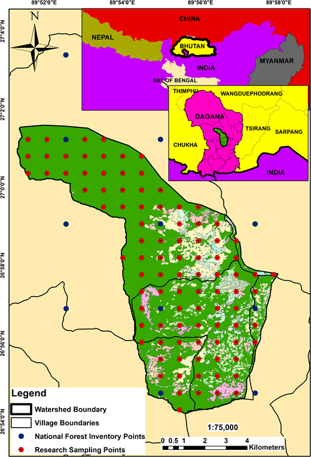

[Open in new tab](https://academic.oup.com/view-large/figure/82914470/cpw065f01.tif)Download slide

Map of the study area showing the location of the inventory plots.

### Data

In 2014, forest stand data were collected from the 96 inventory plots established on a systematic grid of 800 by 800 m within the watershed. The inventory design was adopted from the national forest inventory of Bhutan ([Forest Resources Management Division, 2012](https://academic.oup.com/forestry/article/90/3/367/2958336)). The inventory plots consisted of circular plots with a plot size of 500 m<sup>2</sup> (*r* = 12.62 m) to collect sapling (DBH ≥ 5 to <10 cm) and tree data (DBH ≥ 10 cm). All plot radii were corrected for slope. For every tree within the inventory plot, the name of the species, DBH to the nearest 0.25 cm were measured using a diameter tape, total tree height and height to live crown to the nearest 0.1 m and horizontal distance from the plot centre to the nearest 0.1 cm were measured using the Häglof Vertex Hypsometer and azimuth from the centre of the plot to the tree was measured using a compass. In addition to the tree parameters, elevation, topography, slope, aspect from the plot centre were recorded. Land ownership was recorded in terms of private or Government registration, the management type (community forest management, commercial forest management or private forest management) and the disturbances were recorded by observing any signs of grazing, forest fires or pest attacks.

### The model

Growth models are developed to predict future yield and to explore silvicultural options. Within growth models, diameter growth of a tree is determined by diameter increment or the corresponding tree BAI ([Hann and Larsen, 1991](https://academic.oup.com/forestry/article/90/3/367/2958336)). [Bella (1971)](https://academic.oup.com/forestry/article/90/3/367/2958336) and [West (1980)](https://academic.oup.com/forestry/article/90/3/367/2958336) suggested the use of BAI rather than the diameter increment due to higher *R*<sup>2</sup> values. This approach has been successfully implemented in several individual tree increment models developed by [Monserud and Sterba (1996)](https://academic.oup.com/forestry/article/90/3/367/2958336), [Andreassen and Tomter (2003)](https://academic.oup.com/forestry/article/90/3/367/2958336), [Contreras *et al*. (2011)](https://academic.oup.com/forestry/article/90/3/367/2958336), [Pokharel and Dech (2012)](https://academic.oup.com/forestry/article/90/3/367/2958336) and [da Cunha *et al*. (2015)](https://academic.oup.com/forestry/article/90/3/367/2958336). Similarly for our data, an initial analysis indicated that BAI was a good option for determining the increment for each tree ([Assmann, 1970](https://academic.oup.com/forestry/article/90/3/367/2958336)):

(1)

The observed periodic annual BAI represents the dependent variable as a function of tree size, competition and site variables and forms the basis for all increment models used in predicting tree growth ([Wykoff, 1990](https://academic.oup.com/forestry/article/90/3/367/2958336)):

(2)

where BAI<sub>*i*</sub> is the 5-year periodic mean annual BAI from each tree, *a* is the intercept and *b* is the vector of the coefficients for the tree size variables (Treesize)<sub>i</sub>, *c* are the coefficients for the competition measures (Comp)<sub>i</sub> and *d* are the coefficients for the site factor variables (Site)<sub>i</sub>.

## Analysis

### Species grouping

The data collected in the study included 87 different tree species and it would have been difficult to develop growth functions for each individual species. In such cases, a common solution is to group the species ([Vanclay, 1991](https://academic.oup.com/forestry/article/90/3/367/2958336); [Finegan *et al*., 1999](https://academic.oup.com/forestry/article/90/3/367/2958336); [Akindele and LeMay, 2006](https://academic.oup.com/forestry/article/90/3/367/2958336)). Groupings based purely on taxonomic classification at genus level and/or by commercial factor are not suitable for growth and yield studies. This is because of variations in growth patterns within the same family and the variation in commercial status of trees between sites ([Phillips *et al*., 2002](https://academic.oup.com/forestry/article/90/3/367/2958336)). A more pragmatic approach is to perform cluster analysis using key variables, that indicate similar growth patterns ([Finegan *et al*., 1999](https://academic.oup.com/forestry/article/90/3/367/2958336); [Phillips *et al*., 2002](https://academic.oup.com/forestry/article/90/3/367/2958336); [Zhao *et al*., 2004](https://academic.oup.com/forestry/article/90/3/367/2958336)). In our study, we grouped the 87 species using principal component and cluster anlaysis with predictor variables describing the stand structure, tree growth and species functional attributes such as: (1) average DBH, (2) minimum DBH, (3) maximum DBH, (4) mean 5-year diameter growth increment, (5) maximum 5-year increment, (6) basal area proportion, (7) shade tolerance class and (8) potential height growth class (height range normally obtained by an adult tree) for each species. The shade tolerance characteristics and potential height growth were compiled from available information by species and forest type ([Troup, 1921a](https://academic.oup.com/forestry/article/90/3/367/2958336), [1921b](https://academic.oup.com/forestry/article/90/3/367/2958336), [1921c](https://academic.oup.com/forestry/article/90/3/367/2958336); [Forest Survey of India, 1996](https://academic.oup.com/forestry/article/90/3/367/2958336); [Kliene, 1996](https://academic.oup.com/forestry/article/90/3/367/2958336); [Forest Resources Development Division, 2004](https://academic.oup.com/forestry/article/90/3/367/2958336)). The clustering procedures were carried out in R ([R Core Team, 2015](https://academic.oup.com/forestry/article/90/3/367/2958336)). After standardising the variables, we applied principal component analysis to determine the number of variables required for species grouping. The four selected principal components were then used for the cluster analysis. Cluster analysis was carried out in two parts, first we used the *k* means to determine the number of clusters for our data. We then carried out hierarchical clustering analysis based on the clustering algorithm using ‘single’, ‘complete’, ‘average’ and ‘Ward’ and distance methods with ‘euclidean’ and ‘correlation’. The different clustering algorithms and distance methods were used to choose the best method for grouping our species. The Tukey multiple comparision of means test was used to determine the statistical difference between the groups. The groups were compared based on the mean variables used for grouping the species.

### Computing tree competition measures

Competition indices define the competitive status of the subject tree *vs* its competitors ([Daniels, 1976](https://academic.oup.com/forestry/article/90/3/367/2958336); [Martin and Ek, 1984](https://academic.oup.com/forestry/article/90/3/367/2958336)). They are designed to assess the relationship between individual tree growth *vs* competition as they can be derived from routine inventory data ([da Cunha *et al*., 2015](https://academic.oup.com/forestry/article/90/3/367/2958336)). The competition indices are either distance independent or distance dependent.

### Distance independent indices

For computation of the distance independent competition indices, the spatial location of the trees are not required. It assumes a regular spatial distribution of trees. The two distance independent indices evaluated here are ([Reineke, 1933](https://academic.oup.com/forestry/article/90/3/367/2958336)) stand density index (SDI) and the basal area of the larger trees (BAL) (equations 3 and 4). SDI measures the degree of crowding of trees within a unit area ([Husch *et al*., 2002](https://academic.oup.com/forestry/article/90/3/367/2958336)) while BAL is the sum of the basal area of the trees larger than the subject tree ([Wykoff *et al*., 1982](https://academic.oup.com/forestry/article/90/3/367/2958336)). The BAL is a one sided competition index, based on the assumption that only larger trees compete with the subject tree.

(3)

(4)

### Distance dependent indices

Distance dependent competition indices require spatial locations of trees for their computations. The implementation of distance dependent indices requires a method to define a radius of influence around the subject tree. Trees within the radius of influence are potential competitor trees. Various methods have been used to determine this: (1) fixed radius, (2) crown-influence-zones overlap, (3) DBH angle-gauge method and (4) height angle-gauge methods. In this study, we did not consider the fixed-radius method, as studies have shown that correlation with growth increased when the competitors were selected using the angle gauge or the crown-influence-zone overlap methods ([Bella, 1971](https://academic.oup.com/forestry/article/90/3/367/2958336); [Daniels, 1976](https://academic.oup.com/forestry/article/90/3/367/2958336)). In our study, two DBH angle-gauge methods and two height angle-gauge methods were chosen for determing the radius of influence (maximum radius, MR), which are hereafter referred to as MR 1, MR 2, MR 3 and MR 4. The formula to calculate the radii are provided in Table [1](https://academic.oup.com/forestry/article/90/3/367/2958336). The two DBH angle-gauge methods consists of an approximating formula for 9.2 m<sup>2</sup>/ha (MR 1) and 2 m<sup>2</sup>/ha angle gauge (MR 2). The height angle-gauge method defines a distance to the competitors (Dist<sub>sc</sub>) of a subject tree (s) to those of neighbours (c) whose total height is greater than an imaginary line traced from the subject tree's live crown base with a 45° angle defined as tan 45° (MR 3) or from the foot of the subject tree with a 50° angle defined as tan 50° (MR 4), respectively (Table [1](https://academic.oup.com/forestry/article/90/3/367/2958336)) ([Biging and Dobbertin, 1992](https://academic.oup.com/forestry/article/90/3/367/2958336); [da Cunha *et al*., 2015](https://academic.oup.com/forestry/article/90/3/367/2958336)).

Table 1

Competition index maximum radii evaluated for defining potential competitors used in distance dependent indices

| A tree included as competitor if | Definitions |  |
| --- | --- | --- |
| Dist<sub>sc</sub> ≤ (DBH<sub>s</sub> + DBH<sub>c</sub>)/8 ([Biging and Dobbertin, 1992](https://academic.oup.com/forestry/article/90/3/367/2958336)) | Influence zones of competitor and subject tree overlap approx. 9.2 m<sup>2</sup> ha<sup>−1</sup> angle gauge | MR1 |
| Dist<sub>sc</sub> ≤ 0.33DBH<sub>s</sub> ([Biging and Dobbertin, 1992](https://academic.oup.com/forestry/article/90/3/367/2958336)) | Influence zone of competitor and subject tree overlap approx. 2 m<sup>2</sup> ha<sup>−1</sup> angle gauge | MR2 |
| Dist<sub>sc</sub> ≤ Height<sub>c</sub> − HCB<sub>s</sub> /tan 45<sup>**°**</sup> ([da Cunha *et al*., 2015](https://academic.oup.com/forestry/article/90/3/367/2958336)) | 45° height angle to the horizontal, starting from the crown base of the subject tree | MR3 |
| Dist<sub>sc</sub> ≤ Height<sub>c</sub> /tan 50<sup>**°**</sup> ([Biging and Dobbertin, 1992](https://academic.oup.com/forestry/article/90/3/367/2958336)) | 50° height angle to the horizontal, starting from the foot of the subject tree | MR4 |

DBH is diameter at breast height, H is total height of the tree, HCB is the height to the live crown base, Dist<sub>sc</sub> is the distance between subject tree (s) and competitor tree (c).

[output not shown]

Next, we calculated the competitive situations for our subject tree according to the [Hegyi (1974)](https://academic.oup.com/forestry/article/90/3/367/2958336) index. This approach follows the principle that larger and closer trees will have a higher competitive effect on the subject tree. The index is the sum of the ratio between the DBH of competitor ‘c’ and the subject tree ‘s’ weighted by the horizontal distance in between ‘Dist<sub>sc</sub>’. [Lorimer (1983)](https://academic.oup.com/forestry/article/90/3/367/2958336) found that the competitive status for mixed hardwood stands control would be improved if the distance is raised to the power of 0.5 ([Sabatia and Burkhart, 2012](https://academic.oup.com/forestry/article/90/3/367/2958336); [da Cunha *et al*., 2015](https://academic.oup.com/forestry/article/90/3/367/2958336)):

(5)

For our study, we derived four measures of the competition indices for our subject tree *vs* its potential competitors according to the MR definitions (Table [1](https://academic.oup.com/forestry/article/90/3/367/2958336)). The Hegyi1 and Hegyi2 competition indices were calculated with the potential competitors defined by the angle-gauge methods (MR 1 and 2) while Hegyi3 and Hegyi4 indices were calculated with potential competitors selected using height angle-gauge methods (MR 3 and 4) (Table [1](https://academic.oup.com/forestry/article/90/3/367/2958336)).

### Calibration of tree *BAI* models

BAI is modelled as a function of three factors: tree size, competition and site ([Wykoff, 1990](https://academic.oup.com/forestry/article/90/3/367/2958336)). The main factors of individual tree growth were assessed through an Pearson correlation analysis. Based on the correlation results and the biological processes associated with tree growth, the significant variables of tree size and competition measures were included in the model (equation 2) as presented in:

(6)

where BAI<sub>i</sub> is the 5-year periodic mean annual BAI (cm<sup>2</sup>/year), DBH<sub>i</sub> the diameter at breast height (cm), H<sub>i</sub> the total tree height (m), CL<sub>i</sub> the crown length (m), HD<sub>i</sub> the height-diameter ratio and Hegyi4<sub>i</sub> the competition index.

The biological processes that affect tree growth are fundamentally non-linear (equations 2 and 6) ([Wykoff, 1990](https://academic.oup.com/forestry/article/90/3/367/2958336)). For modelling tree growth, non-linear regression (nls), multiple linear regression (lm) or generalised linear model (glm) have been used ([Wykoff, 1990](https://academic.oup.com/forestry/article/90/3/367/2958336); [Monserud and Sterba, 1996](https://academic.oup.com/forestry/article/90/3/367/2958336); [Gea-Izquierdo and Canellas, 2009](https://academic.oup.com/forestry/article/90/3/367/2958336); [da Cunha *et al*., 2015](https://academic.oup.com/forestry/article/90/3/367/2958336)). In our preliminary analysis (not shown), we observed that the multiple linear regression resulted in strong biases associated with the logarithmic transformation of the dependent variable (BAI<sub>i</sub>, cm<sup>2</sup>/year). Both nls and glm methods do not require any transformation of data. For our available data the glm with log-link function and gamma distribution provided the best model predictions (see also [Gea-Izquierdo and Canellas, 2009](https://academic.oup.com/forestry/article/90/3/367/2958336); [Contreras *et al*., 2011](https://academic.oup.com/forestry/article/90/3/367/2958336); [da Cunha *et al*., 2015](https://academic.oup.com/forestry/article/90/3/367/2958336)).

For each species group, we started with a full set of variables (equation 6) and removed one variable after the other, each with a separate glm regression run carried out in R ([R Core Team, 2015](https://academic.oup.com/forestry/article/90/3/367/2958336)). We removed those variables which were not significant at *α* = 0.05 and with a variance inflation factor (VIF) of more than five. VIF is an indicator for multicollinearity between the predictor variables. A VIF of more than five indicates strong multicollinearity which can produce misleading results ([Marquardt, 1970](https://academic.oup.com/forestry/article/90/3/367/2958336); [Snee, 1973](https://academic.oup.com/forestry/article/90/3/367/2958336); [Van Laar, 1991](https://academic.oup.com/forestry/article/90/3/367/2958336)).

### Model plausibility test and applications

Due to the lack of an independent dataset for model validation, we carried out plausibility tests for our calibrated models ([da Cunha *et al*., 2015](https://academic.oup.com/forestry/article/90/3/367/2958336)). We specifically tested the biological realism of the models by species groups ([Zhao *et al*., 2004](https://academic.oup.com/forestry/article/90/3/367/2958336)) and the practical applicability of the models for sustainable forest management. The results from the regression runs were applied to the range of the available data (Table [2](https://academic.oup.com/forestry/article/90/3/367/2958336)) to predict tree growth. We tested the influence of (1) DBH and (2) Hegyi competition indices on the resulting BAI for each species group as follows: (1) for the BAI – DBH relationship, the Hegyi competition index was set to the mean value and (2) for BAI – Hegyi competition index, the DBH was set to its mean value.

Table 2

Summary statistics of the data showing mean ± SD and range (minimum and maximum in parenthesis) available for the study area

| Variables | Species groups Group 1 | Species groups Group 2 | Species groups Group 3 | Species groups Group 4 |
| --- | --- | --- | --- | --- |
| *N* | 98 | 90 | 130 | 111 |
| DBH (cm) | 33.9 ± 23.8 (10–105) | 36.6 ± 25.3 (10.3–108.5) | 25.3 ± 14.4 (10–86) | 19.7 ± 11.5 (10.1–80) |
| *H* (m) | 18.8 ± 8.5 (5.5–39.7) | 20.2 ± 9.1 (5.9–38.7) | 15.2 ± 5.8 (4.3–35) | 11 ± 4.8 (3–27.1) |
| *CL* (m) | 10.7 ± 6.3 (1.7–33.7) | 11.3 ± 6.7 (2.2–30.7) | 8.9 ± 4.4 (1.2–23.3) | 6.3 ± 3.4 (1.2–19.9) |
| *HD* | 68.5 ± 31.5 (15.3–202.2) | 68.9 ± 29 (13–147) | 69.2 ± 27 (23.7–148.8) | 60.6 ± 20.6 (16.9–111.2) |
| BAI (cm<sup>2</sup>/year) | 28.5 ± 27.5(2.2–133.7) | 23.5 ± 25.9 (0.2–149.5) | 18.3 ± 15.2 (0.9–76.8) | 14.3 ± 12.6 (0.7–66.4) |
| Hegyi1 | 3.6 ± 3.4 (0–16.7) | 3.8 ± 3.1 (0–14.6) | 3.7 ± 3.3 (0–13.9) | 3.8 ± 4.2 (0–21.7) |
| Hegyi2 | 3.4 ± 2.5 (0–12.7) | 3 ± 2.5 (0–14.6) | 3 ± 2.4 (0–11.2) | 3.3 ± 3.4 (0–18.7) |
| Hegyi3 | 4.6 ± 5.5 (0–27.3) | 4.9 ± 4.9 (0–20.5) | 5.6 ± 5.5 (0–25) | 5.9 ± 5.9 (0–28.4) |
| Hegyi4 | 6.3 ± 6.3 (0–28.3) | 6.7 ± 5.9 (0–23.6) | 7 ± 6 (0–25.7) | 7 ± 6.8 (0–33.6) |
| BAL (m<sup>2</sup>/ha) | 25.9 ± 24.4 (0–97.6) | 28.5 ± 21.7 (0–97.3) | 26.3 ± 22.5 (0–78.2) | 22.6 ± 24.2 (0–97.8) |
| SDI | 1.3 ± 0.8 (0.03–2.9) | 1.4 ± 0.6 (0.04–2.9) | 1.2 ± 0.8 (0.1–2.9) | 1 ± 0.8 (0.01–2.9) |
| Slope (<sup>**o**</sup>) | 28.9 ± 9.1 (10–52.5) | 26.9 ± 10.8 (5–61) | 27.8 ± 10.9 (3–61) | 31.3 ± 11.5 (3–61) |
| Elevation | 1733 ± 23.8 (815–2413) | 1814 ± 297 (933–2413) | 1720 ± 399.6 (906–2413) | 1640 ± 436.5 (872–2413) |

*N* = Number of observations, DBH is diameter at breast height, *H* is total tree height, CL is crown length, HD is height to diameter ratio, BAI is basal area increment, Hegyi1, Hegyi2, Hegyi3 and Hegyi4 are competition indices with different search radius, BAL is area in the larger trees and SDI is stand density index.

[output not shown]

The competitive status of the forest stand altered the growth prediction significantly, hence we compared tree productivity (equation 7) with the competition index and derived how a given competitive status will affect tree growth. We derived three different competitive levels using the Hegyi competition index ([Hegyi, 1974](https://academic.oup.com/forestry/article/90/3/367/2958336)) (equation 5) which are hereafter referred to competition level 1 (CP 1), competition level 2 (CP 2) and competition level 3 (CP 3) (Table [5](https://academic.oup.com/forestry/article/90/3/367/2958336)). The competition level boundaries were set in such a way that every species group had enough replicates in every competition level. We calculated the competition index for each subject tree and then accordingly assigned the tree to one of the three defined competition levels. Next, the BAI productivity potential (PBAI<sub>i</sub>) was calculated by species groups under the three different competition levels:

(7)

where PBAI % is the percentage of 5-year mean annual BAI of a given tree *vs* the basal area of the tree, BAI<sub>i</sub> is the basal area increment and BA<sub>i</sub> is the basal area of the subject tree at the beginning of the growing period.

From a forest management perspective, it may be important to know the time required to achieve a certain target diameter. By using the results from our increment model and the productivity rate (PBAI %) as determined in equation 7, we estimated the number of years (*t*) required for a tree to grow from a tree with a basal area corresponding to 40 cm in DBH (BA<sub>i</sub>) to a tree with a basal area corresponding to 70 cm in DBH (BA<sub>i+1</sub>).

(8)

where ln is the natural logarithm, *t* is the number of years required for a tree to grow from a basal area corresponding to 40 cm in DBH (BA<sub>*i*</sub>) to a basal area corresponding to 70 cm in DBH (BA<sub>*i*+1</sub>) and PBAI % is from equation 7.

## Results and discussion

### Species groups

The cluster analysis ([Phillips *et al*., 2002](https://academic.oup.com/forestry/article/90/3/367/2958336); [Zhao *et al*., 2004](https://academic.oup.com/forestry/article/90/3/367/2958336)) using the variable stand structure, tree growth and species functional attributes resulted in a grouping of the 87 broadleaved tree species into four species groups (Table [2](https://academic.oup.com/forestry/article/90/3/367/2958336); Appendix 1). The Tukey multiple test revealed significant differences between the four species group, hereafter referred to as: species group 1 (upper canopy species with fast growth), group 2 (upper canopy species), group 3 (middle canopy) and group 4 (understorey species). The four groups consist of 17, 16, 30 and 24 species, respectively ( Appendix 1). The number of observations of species in group 1 was 98, in group 2 it was 90, in group 3 it was 130 and in group 4 there were 111 trees (Table [2](https://academic.oup.com/forestry/article/90/3/367/2958336)). Species functional attributes reflecting the shade tolerance of the species and potential height growth class ensured that our four species groups are based on ecologically meaningful groupings (Figure [2](https://academic.oup.com/forestry/article/90/3/367/2958336); Appendix 1). For the first time in Bhutan, more than 80 broadleaved tree species are grouped to four classes to allow an ecologically and silviculturally meaningful forest management approach based on tree growth. This species grouping is new and provides a simplification which allows the development of growth models as a tool for sustainable forest management of broadleaved forests in Bhutan.

Figure 2

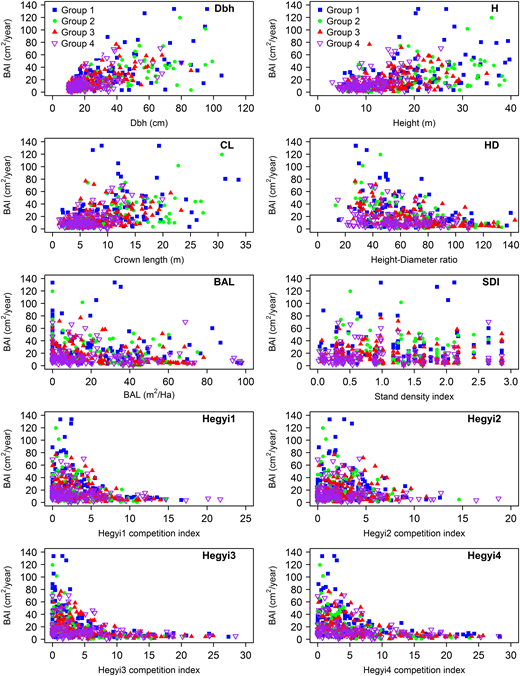

[Open in new tab](https://academic.oup.com/view-large/figure/82914498/cpw065f02.tif)Download slide

Scatter plots of BAI *vs* DBH, Height (H), CL, HD, BAL, SDI, Hegyi1, Hegyi2, Hegyi3 and Hegyi4 competition indices for all four species groups.

### Tree competition measures

The correlation analysis between 5-year BAI (cm<sup>2</sup>/year) and tree size and competition variables exhibited significant relationships for the DBH, H, CL, HD-ratio, the distance dependent Hegyi index and the distance independent competition index BAL (Table [3](https://academic.oup.com/forestry/article/90/3/367/2958336); Figure [2](https://academic.oup.com/forestry/article/90/3/367/2958336)). However, the distance dependent indices based on the approach suggested by [Hegyi (1974)](https://academic.oup.com/forestry/article/90/3/367/2958336) generally show higher correlations than the two distance independent indices. This suggests that spatial information (e.g. tree location) for defining the competition of a tree *vs* its competitors increases the accuracy of describing the competition status of trees within forests ([Rautiainen, 1999](https://academic.oup.com/forestry/article/90/3/367/2958336); [Rautiainen *et al*., 2000](https://academic.oup.com/forestry/article/90/3/367/2958336); [Contreras *et al*., 2011](https://academic.oup.com/forestry/article/90/3/367/2958336); [Sharma *et al*., 2016](https://academic.oup.com/forestry/article/90/3/367/2958336)) and thus the predictive power of the growth models. Distance independent indices are mainly applied within even-aged forests or plantations.

Table 3

Pearson correlation between BAI *vs* DBH, total tree height (H), CL, HD, distance dependent indices of Hegyi (Hegyi1, Hegyi2, Hegyi3 and Hegyi4), BAL and SDI; all correlations are significant at *α* = 0.05 unless indicated as ns (non-significant).

| Variables | Species groups Group 1 | Species groups Group 2 | Species groups Group 3 | Species groups Group 4 |
| --- | --- | --- | --- | --- |
| DBH (cm) | 0.54 | 0.76 | 0.68 | 0.57 |
| H (m) | 0.50 | 0.44 | 0.36 | 0.46 |
| CL (m) | 0.47 | 0.45 | 0.35 | 0.53 |
| HD | −0.36 | −0.61 | −0.49 | −0.18 |
| Hegyi1 | −0.43 | −0.49 | −0.36 | −0.23 |
| Hegyi2 | −0.34 | −0.15<sup>ns</sup> | −0.03<sup>ns</sup> | −0.14<sup>ns</sup> |
| Hegyi3 | −0.49 | −0.60 | −0.48 | −0.32 |
| Hegyi4 | −0.49 | −0.63 | −0.49 | −0.30 |
| BAL (m<sup>2</sup>ha<sup>−1</sup>) | −0.30 | −0.45 | −0.38 | −0.20 |
| SDI | −0.14<sup>ns</sup> | −0.18<sup>ns</sup> | −0.10 <sup>ns</sup> | −0.11<sup>ns</sup> |

[output not shown]

The relationship between the BAI *vs* the Hegyi competition indices (Figure [2](https://academic.oup.com/forestry/article/90/3/367/2958336)) exhibited an exponential decline with increasing competition for each species group. This provides good evidence that the Hegyi competition indices can be used to define the competition level for individual tree growth modelling of species stands in Bhutan. The Hegyi index (1974) was initially developed for pure uniform stands but it was later found to be applicable in mixed hardwood stands ([Lorimer, 1983](https://academic.oup.com/forestry/article/90/3/367/2958336); [da Cunha *et al*., 2015](https://academic.oup.com/forestry/article/90/3/367/2958336)), so our study is not the first time the index has been used in mixed species stands.

The implementation of distance dependent indices requires appropriate methods to select potential competitors for the subject tree. Thus, the Hegyi1 and Hegyi2 competition indices were calculated with potential competitors selected using the DBH angle-gauge methods and Hegyi3 and Hegyi4 with the potential competitors selected using the height angle-gauge methods. From the four variants of the Hegyi competition indices, the Hegyi3 and Hegyi4 correlated best with BAI (Table [3](https://academic.oup.com/forestry/article/90/3/367/2958336): Figure [2](https://academic.oup.com/forestry/article/90/3/367/2958336)). This indicates that tree height, which is a measure of a trees capacity to intercept light, is a better measure of competition compared with diameter (DBH) in the forests of Dagana, Bhutan and is consistent with previous findings by [Bella (1971)](https://academic.oup.com/forestry/article/90/3/367/2958336), [Daniels (1976)](https://academic.oup.com/forestry/article/90/3/367/2958336) and [Biging and Dobbertin (1992)](https://academic.oup.com/forestry/article/90/3/367/2958336).